# Identifying Red Kite feeding sites from tracking data

Steffen Oppel

# Background

The Red Kite is a widespread raptor in Switzerland that benefits from anthropogenic food supplementation. To better understand the spatial extent of anthropogenic food provisioning we are using the tracking data of Red Kites to identify places where the tracked behaviour of kites is consistent with the recorded behaviour of tracked kites at known anthropogenic feeding sites. This work is based on the MSc thesis of Nathalie Heiniger (2020), and uses data from Eva Cereghetti and Fiona Pelle for validation of predicted patterns.

# Data preparation

The data we are using are hourly red kite tracking data from 2016 - 2022, which we first filter to the extent of Switzerland to remove locations during migration and in winter, resulting in 949489 GPS locations. The tracking locations are converted into tracks and metrics such as step length, speed, and turning angle are calculated for each step (between two subsequent GPS locations) to extract information on the behaviour of the bird, as presence at a feeding site would typically involve slow speeds, short step lengths and high turning angles. The tracking data are then spatially intersected with land cover data, specifically to remove locations in forests (where birds nest, but where anthropogenic feeding is unlikely), and select locations near human settlements. All locations within 2810 forest fragments are removed, and only locations within 50 m of 4976 buildings larger than 65 sqm are retained. In addition, the location of 6460 anthropogenic feeding stations are known (which includes all experimental feeding instances), and GPS locations within 50 m of these feeding stations are used to train a model to detect feeding stations. As a result of the various steps, we have a total of 149520 GPS locations and 3541 of these locations near a known anthropogenic feeding station (including temporal overlap for all experimental feeding stations for which the time of food provisioning was available).

# Approach to analysis

Anthropogenic feeding stations attract Red Kites regularly, and there will therefore be data patterns at multiple hierarchical levels that could indicate the presence of an anthropogenic feeding site. At the individual level, locations with low speed, high turning angles, and high and consistent revisitation rates over the whole season should be indicative of a feeding place. However, such locations may occur in many places and be indicative of both natural and artificial foraging areas. Thus, the accumulation of several individuals in one place over the season is an additional criterion to consider.

We therefore proceed in two steps, in the first step we use the filtered tracking data in a random forest model to predict whether locations occurred within a known anthropogenic feeding area or not. This model will rely on 19 variables and be tuned for high sensitivity, given that the knowledge of anthropogenic feeding areas is not exhaustive, and birds may behave similarly in areas without anthropogenic feeding.

# Validation

To assess whether the predictions are reliable, we draw on two interview datasets where members of the public were asked (by Eva Cereghetti and Fiona Pelle) whether they feed red kites or other scavengers. From those two theses we have 71 grid cells with known feeding locations available that were not used for training the models, and can therefore be used for validation.

We use two metrics of validation, because the validation data can only indicate the *presence* (but not the *absence*) of a feeding location. First, we use the area under the receiver-operated characteristic curve (AUC), which is a threshold-independent metric for classification, but requires both presence and absence validation data. Thus, we would expect the value of the AUC to be lower than what is typically considered ‘good’ (0.8). However, we can use the curve to identify the optimal threshold of probability that maximizes sensitivity and specificity, and then use that threshold for the binary classification. Using the ROC-derived threshold we then calculate the proportion of grid cells with a known anthropogenic feeding location that were correctly predicted.

# Results

The hourly tracking data were randomly split into 100177 locations for training the first random forest model, and 49343 locations for validation, and the sensitivities reported here are on test data not used to train the model.

The random forest model classified 1127 of 1169 known presences at anthropogenic feeding stations correctly (96.4 %), but also predicted that 2606 of 48174 other GPS locations (but not within 50 m of a known feeding station) were consistent with criteria that could indicate that Red Kites were feeding there. The variables that contributed the most to classifying GPS locations as near a feeding station are shown in this graph:

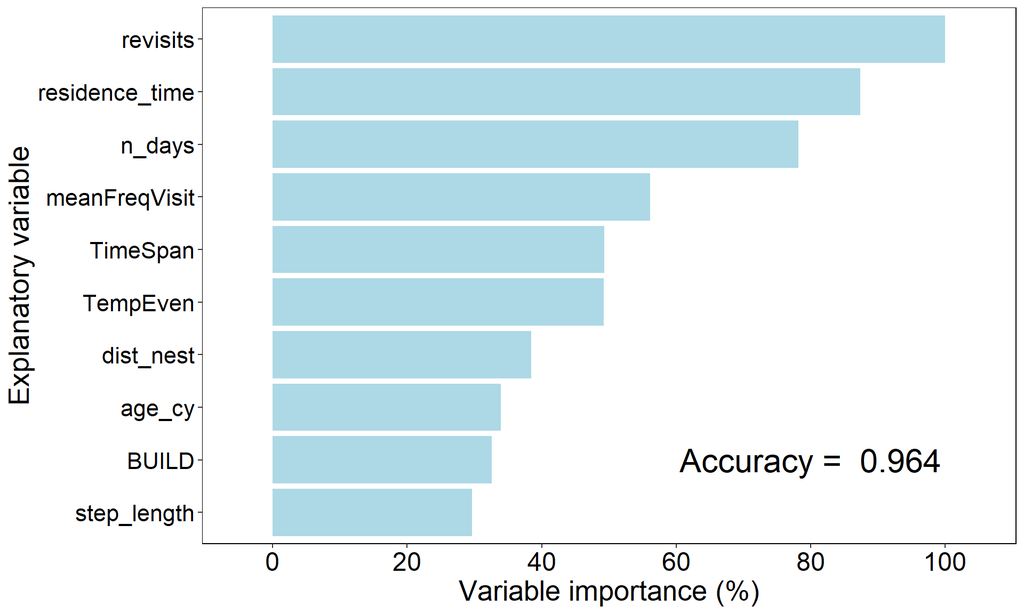

*Fig. 1: Relative variable importance to predict whether GPS locations are associated with anthropogenic feeding sites*

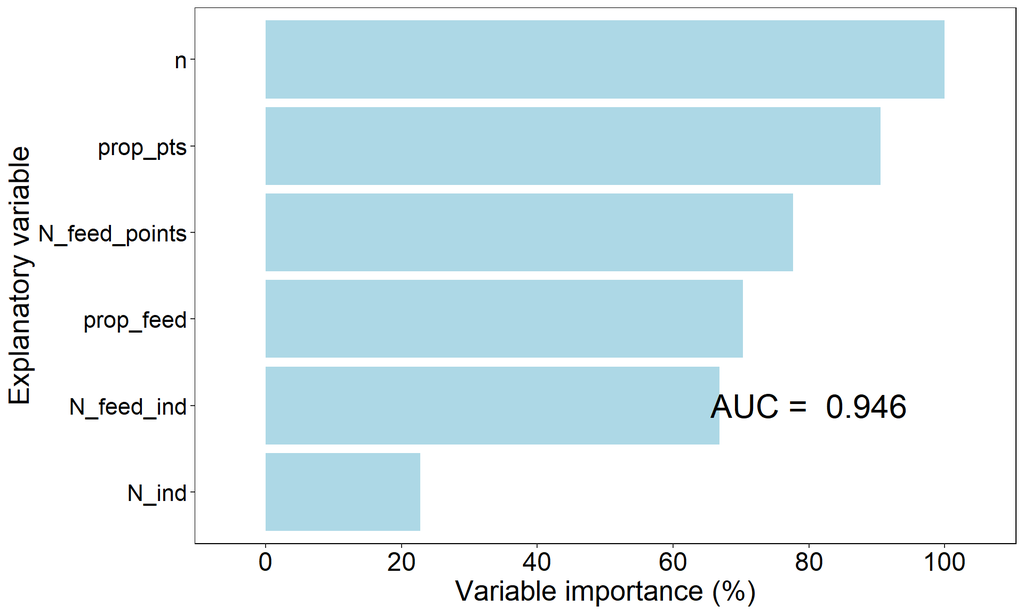

*Fig. 2: Relative variable importance to predict whether anthropogenic feeding sites exist in grid cells*

The validation data consisted of a list of known feeding locations obtained by interviews. Although some interviews also revealed that certain households were *not* feeding red kites, these data are not suitable to validate predicted ‘absences’ because they cannot exclude that other households or farms in a grid cell may have been providing food. We therefore focussed on the proportion of correctly identified feeding locations as identified from interviews to validate the predictions of our model. There were a total of 71 grid cells with a known feeding location (from interviews) within the area covered by sufficient red kite tracking data, and 60.6% of these were correctly predicted (Fig. 3).

[interactive chart not shown]

*Fig. 3: Map of predicted probability of the presence of anthropogenic feeding sites in the main Red Kite study area Switzerland. Dark green points indicate known feeding locations that were used to train models, small grey dots indicate Red Kite GPS locations that were classified as feeding behaviour, and bright red and green points are validation data (feeding locations obtained from interviews that were used to evaluate the predictions).*

# Reliability of prediction

To assess whether the predictions are reliable, we draw on the 71 known feeding locations that were not used for training the models (interviews), of which 39.4% were not predicted with our tracking data. We then explored potential explanatory variables differentiating between correct and missed predictions (Fig. 4).

The single most important factor for failing to predict a known feeding location was data scarcity (Fig. 4). Grid cells with a ‘missed’ prediction had generally fewer GPS points overall, from fewer individuals, and a fewer total number of GPS locations with feeding behaviour. Correct predictions of anthropogenic feeding locations had a minimum of 20 GPS locations from a minimum of 6 individuals within a given 500 m grid cell.

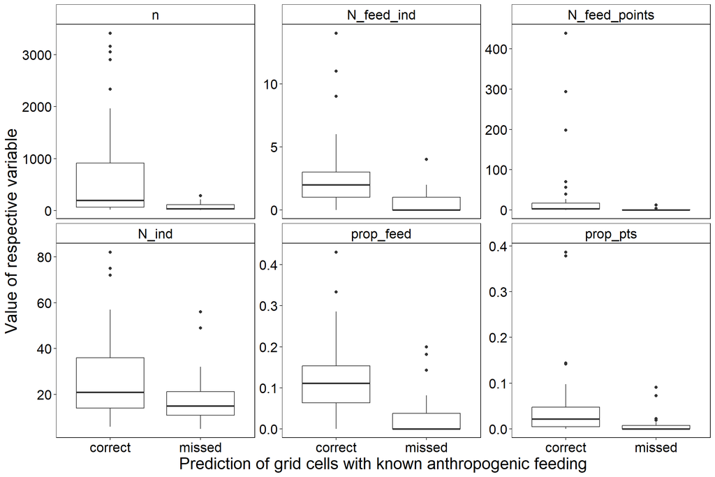

*Fig. 4: Boxplot of the value of predictor variables (number of GPS points and individuals in each grid cell, both total and with ‘feeding’ behaviour) at known feeding locations that were either correctly predicted or missed (predicted probability < threshold).*

# Projection across Switzerland

We used the two models above to project the existence of anthropogenic feeding locations across Switzerland. To avoid computational burdens beyond the extent of our tracking data, we first reduced Switzerland to those 4772 grid cells with a minimum of 20 Red Kite GPS locations, which eliminated 98.67% of Swiss grid cells from predictions. Of those grid cells with sufficient data, 16.54% were predicted to contain anthropogenic feeding stations with a probability exceeding the threshold for optimal sensitivity (Fig. 5).

[interactive chart not shown]

*Fig. 5: Map of the predicted probability of the presence of anthropogenic feeding sites in Switzerland based on Red Kite GPS tracking data. Grid cells with a red frame exceed the threshold for a positive prediction (=feeding area is likely), and all grid cells with colour have the minimum of 20 GPS locations.*

Thus, while we are able to extrapolate the extent of anthropogenic food supplementation for Red Kites based on tracking data, these projections are fundamentally limited by the amount of tracking data available and may be very sparse outside of our main study area. Nonetheless, for our study population we can now quantify the proportion of daytime that Red Kites spend in grid cells with a high predicted probability of containing an anthropogenic feeding site as a proxy for their ‘sociality’ or ‘dependence’, and relate that proxy to survival, residence, and breeding success.